# An Introduction to Functional Analysis

Alex Sanchez and Ferran Brianso

April 25th 2018

```r
installifnot <- function (packageName){
 if (!(require(packageName, character.only=TRUE))) {
    install.packages(packageName)
  }else{
    detach(paste ("package", packageName, sep=":"), character.only=TRUE)
  }
}
bioCifnot <- function (packageName){
 if (!(require(packageName, character.only=TRUE))) {
    source("http://bioconductor.org/biocLite.R")
    biocLite(packageName)
 }else{
  detach(paste ("package", packageName, sep=":"), character.only=TRUE)
  }
}
installifnot("knitr")
bioCifnot ("annotate")
bioCifnot ("org.Hs.eg.db")
bioCifnot ("hgu133a.db")
bioCifnot ("GO.db")
bioCifnot ("GOstats")
```

# Introduction

This document provides *some examples* on the analyses that can be perfomed on one or more gene lists to help gain biological insight on the results of a differential expression analysis. Overall these analyses are known as *Functional Analysis*.

Functional analysis can be performed in many different ways that lead to similar (or not-so-similar) results. Because there is not a universal acceptance of what is a *complete, well done functional analysis* some different approaches will be shown.

## Input Data for Functional Analysis

Functional analysis can be made, on a first approach on

- A list of genes selected by being differentially expressed in a given experimental setting.
- The whole list of genes -or even the whole expression matrix- that has been used in the analysis.

Most tools require that gene list consist of gene identifiers in some standard notation such as `Entrez`, `ENSEMBL` or other related to these.

These gene lists can be usually extracted from output tables provided by microarrays or RNA-seq data analysis tools.

## Read data

We start by reading two files that contain the expression values (`expres_AvsB.csv`) and the results (`Top_AvsB.csv`) of a differential expression analysis erformed using microarrays.

The code and text for the analysis that, using these data, generated these tables, can be found at: https://github.com/alexsanchezpla/Ejemplo_de_MDA_con_Bioconductor

The code below assumes the files have been stored in a subdirectory of the current folder named `datasets`. Alternatively they can be read-onthe-fly

```r
topTabAvsB <- read.csv2("datasets/Top_AvsB.csv2", row.names=1)
expresAvsB <- read.csv2 ("datasets/expres_AvsB.csv2", row.names=1)

dim(topTabAvsB); head(topTabAvsB)
```

```
## [1] 6218    6
```

```
##                 logFC  AveExpr          t      P.Value    adj.P.Val         B
## 204667_at   -3.038344 8.651157 -14.361559 5.741537e-11 3.570088e-07 14.649763
## 215729_s_at  3.452290 6.137595  12.814617 3.438484e-10 1.069025e-06 13.150062
## 220192_x_at -3.016315 9.521883 -10.859041 4.336167e-09 7.020345e-06 10.929050
## 214451_at   -5.665059 7.432823 -10.829695 4.516144e-09 7.020345e-06 10.892594
## 217528_at   -5.622086 6.763101  -9.666279 2.429965e-08 3.021904e-05  9.364339
## 217284_x_at -4.313116 9.133307  -9.528468 2.994504e-08 3.103304e-05  9.172112
```

```r
dim(expresAvsB); head(expresAvsB)
```

```
## [1] 6218   10
```

```
##             GSM26878.CEL GSM26883.CEL GSM26887.CEL GSM26903.CEL GSM26910.CEL GSM26888.CEL
## 204667_at       9.822291     9.514461     9.919010     9.600700     9.592063     6.483792
## 215729_s_at     4.736669     4.761001     6.254886     4.820416     4.848366     8.265870
## 220192_x_at    10.484295    10.914847    10.510820    11.509958    10.265186     7.823961
## 214451_at      10.176920    10.060391    11.201140    10.888825    10.403751     4.818335
## 217528_at      10.533946    10.036022    11.325578     8.053482    10.618710     4.580566
## 217284_x_at    11.726573     9.740720    11.436035    12.818812    12.686506     7.274321
##             GSM26889.CEL GSM26892.CEL GSM26898.CEL GSM26906.CEL
## 204667_at       6.551345     7.001161     6.685062     6.535446
## 215729_s_at     8.962679     8.304247     8.768668     8.381325
## 220192_x_at     7.809752     7.522203     8.427221     7.020395
## 214451_at       4.784154     4.975607     4.912010     4.915627
## 217528_at       4.537627     4.518766     4.357199     4.463147
## 217284_x_at     7.298390     7.490518     7.562369     7.217467
```

# Exploring gene lists

A gene list contains useful information that can be extracted by querying databases.

Let us see how we can obtain information fom the *genes* probes in table (comparison) `AvsB`.

```r
myProbes <- rownames(expresAvsB)
head(myProbes)
```

```
## [1] "204667_at"   "215729_s_at" "220192_x_at" "214451_at"   "217528_at"   "217284_x_at"
```

We need to load the library (“package”) that contains specific annotations for the microarray model that was used in this study. It has to be noticed also that each row does not represent a gene, but a probe, a sequence that has been designed to detect if a gene is expressed. microarrays contain multiple probes for many genes and this is something that ha to be dealt with.

## ID conversion

In order to do most analyses it is convenient to use a universally accepted identifier such as Entrez or ENSEMBL. For instance Bioconductor organism annotation packages rely on Entrez identifiers as main key for most mappings.

It is possible to find out easily which mappings are available for each ID

```r
require(hgu133a.db)
keytypes(hgu133a.db)
```

```
##  [1] "ACCNUM"       "ALIAS"        "ENSEMBL"      "ENSEMBLPROT"  "ENSEMBLTRANS" "ENTREZID"
##  [7] "ENZYME"       "EVIDENCE"     "EVIDENCEALL"  "GENENAME"     "GO"           "GOALL"
## [13] "IPI"          "MAP"          "OMIM"         "ONTOLOGY"     "ONTOLOGYALL"  "PATH"
## [19] "PFAM"         "PMID"         "PROBEID"      "PROSITE"      "REFSEQ"       "SYMBOL"
## [25] "UCSCKG"       "UNIGENE"      "UNIPROT"
```

Annotation packages make it possible to annotate genes and in a similar manner other omics features. For example we can obtain gene symbol, entrez ID and gene name with a single SQL instruction.

```r
geneAnots <- select(hgu133a.db, myProbes, c("SYMBOL", "ENTREZID", "GENENAME"))
head(geneAnots)
```

```
##       PROBEID SYMBOL ENTREZID                                               GENENAME
## 1   204667_at  FOXA1     3169                                        forkhead box A1
## 2 215729_s_at  VGLL1    51442                         vestigial like family member 1
## 3 220192_x_at  SPDEF    25803 SAM pointed domain containing ETS transcription factor
## 4   214451_at TFAP2B     7021                         transcription factor AP-2 beta
## 5   217528_at  CLCA2     9635                           chloride channel accessory 2
## 6 217284_x_at SERHL2   253190                                serine hydrolase like 2
```

## Differentially expressed genes

We are often interested in “differentially expressed genes”, that is those genes that can be considered to express differently between two conditions. It is straightforward to select those genes from a results “topTable” by taking those whose p-value is below a given threshold. Eventually we may require that there is besides a minimum effect size.

```r
selected<- topTabAvsB[,"adj.P.Val"]<0.01 & abs(topTabAvsB[,"logFC"]) > 1
sum(selected)
```

```
## [1] 181
```

```r
selectedTopTab <- topTabAvsB[selected,]
head(selectedTopTab)
```

```
##                 logFC  AveExpr          t      P.Value    adj.P.Val         B
## 204667_at   -3.038344 8.651157 -14.361559 5.741537e-11 3.570088e-07 14.649763
## 215729_s_at  3.452290 6.137595  12.814617 3.438484e-10 1.069025e-06 13.150062
## 220192_x_at -3.016315 9.521883 -10.859041 4.336167e-09 7.020345e-06 10.929050
## 214451_at   -5.665059 7.432823 -10.829695 4.516144e-09 7.020345e-06 10.892594
## 217528_at   -5.622086 6.763101  -9.666279 2.429965e-08 3.021904e-05  9.364339
## 217284_x_at -4.313116 9.133307  -9.528468 2.994504e-08 3.103304e-05  9.172112
```

It is straightforward to annotate these genes adding Entrez, Gene Symbol or Gene Description to the table.?

```r
selectedProbes <- rownames(selectedTopTab)
selectedAnots <-  select(hgu133a.db, selectedProbes, c("SYMBOL", "ENTREZID", "GENENAME"))
head(selectedAnots)
```

```
##       PROBEID SYMBOL ENTREZID                                               GENENAME
## 1   204667_at  FOXA1     3169                                        forkhead box A1
## 2 215729_s_at  VGLL1    51442                         vestigial like family member 1
## 3 220192_x_at  SPDEF    25803 SAM pointed domain containing ETS transcription factor
## 4   214451_at TFAP2B     7021                         transcription factor AP-2 beta
## 5   217528_at  CLCA2     9635                           chloride channel accessory 2
## 6 217284_x_at SERHL2   253190                                serine hydrolase like 2
```

```r
selectedTopTab2 <- cbind(PROBEID=rownames(selectedTopTab),  selectedTopTab)
selectedInfo <- merge (x= selectedAnots, y = selectedTopTab2,
                       by.x="PROBEID", by.y="PROBEID")
head(selectedInfo)
```

```
##       PROBEID SYMBOL ENTREZID                        GENENAME     logFC  AveExpr         t
## 1   200670_at   XBP1     7494         X-box binding protein 1 -1.835725 10.88536 -6.223403
## 2   200862_at DHCR24     1718 24-dehydrocholesterol reductase -2.685167 10.73172 -6.096542
## 3   200961_at SEPHS2    22928    selenophosphate synthetase 2 -1.322764 10.77360 -6.193821
## 4   200972_at TSPAN3    10099                   tetraspanin 3  1.029474 10.55080  4.763469
## 5 201030_x_at   LDHB     3945         lactate dehydrogenase B  2.137083 11.81404  5.666284
## 6 201131_s_at   CDH1      999                      cadherin 1 -1.210944 11.58977 -4.791580
##        P.Value   adj.P.Val         B
## 1 9.062432e-06 0.001657359 3.7587000
## 2 1.161438e-05 0.001768323 3.5187679
## 3 9.600348e-06 0.001658194 3.7029590
## 4 1.779731e-04 0.007528141 0.8698846
## 5 2.737246e-05 0.002540328 2.6881372
## 6 1.676739e-04 0.007342228 0.9277873
```

```r
write.csv2(selectedInfo, file="selectedTopTab_AvsB.csv2")
```

# From gene lists to pathway analysis

See http://ithake.eu/2012/09/on-the-exploration-of-a-list-of-genes/ for a simple, external, motivation on why we may want to move from gene-by-gene analysis to gene-set analyses.

## Basic GO Annotation

Bioconductor libraries allow for both: - Exploration of functional information on genes based on the Gene Ontology - Different types of Gene Enrichment and Pathway Analysis based on the GO or other pathway databases such as the KEGG, Reactome etc.

The code below shows some easy ways to retrieve GO information associated with genes

Start by loading the appropriate packages

Select the “top 5” genes from the list

```r
probes <- rownames(topTabAvsB)[1:5]
genes <-selectedAnots[1:5,"ENTREZID"]
```

Select the GO Terms associated with thes IDs

```r
keytypes(hgu133a.db)
```

```
##  [1] "ACCNUM"       "ALIAS"        "ENSEMBL"      "ENSEMBLPROT"  "ENSEMBLTRANS" "ENTREZID"
##  [7] "ENZYME"       "EVIDENCE"     "EVIDENCEALL"  "GENENAME"     "GO"           "GOALL"
## [13] "IPI"          "MAP"          "OMIM"         "ONTOLOGY"     "ONTOLOGYALL"  "PATH"
## [19] "PFAM"         "PMID"         "PROBEID"      "PROSITE"      "REFSEQ"       "SYMBOL"
## [25] "UCSCKG"       "UNIGENE"      "UNIPROT"
```

```r
columns(hgu133a.db)
```

```
##  [1] "ACCNUM"       "ALIAS"        "ENSEMBL"      "ENSEMBLPROT"  "ENSEMBLTRANS" "ENTREZID"
##  [7] "ENZYME"       "EVIDENCE"     "EVIDENCEALL"  "GENENAME"     "GO"           "GOALL"
## [13] "IPI"          "MAP"          "OMIM"         "ONTOLOGY"     "ONTOLOGYALL"  "PATH"
## [19] "PFAM"         "PMID"         "PROBEID"      "PROSITE"      "REFSEQ"       "SYMBOL"
## [25] "UCSCKG"       "UNIGENE"      "UNIPROT"
```

```r
info1<- select(hgu133a.db, keys=probes[1],
                  columns = c("ENTREZID", "SYMBOL","GO"),
                  keytype="PROBEID")
dim(info1)
```

```
## [1] 45  6
```

```r
head(info1, n=20)
```

```
##      PROBEID ENTREZID SYMBOL         GO EVIDENCE ONTOLOGY
## 1  204667_at     3169  FOXA1 GO:0000122      IEA       BP
## 2  204667_at     3169  FOXA1 GO:0000981      IBA       MF
## 3  204667_at     3169  FOXA1 GO:0001077      ISS       MF
## 4  204667_at     3169  FOXA1 GO:0001650      IDA       CC
## 5  204667_at     3169  FOXA1 GO:0003677      IDA       MF
## 6  204667_at     3169  FOXA1 GO:0003700      TAS       MF
## 7  204667_at     3169  FOXA1 GO:0005515      IPI       MF
## 8  204667_at     3169  FOXA1 GO:0005634      IDA       CC
## 9  204667_at     3169  FOXA1 GO:0005654      IDA       CC
## 10 204667_at     3169  FOXA1 GO:0005902      IEA       CC
## 11 204667_at     3169  FOXA1 GO:0006338      ISS       BP
## 12 204667_at     3169  FOXA1 GO:0006366      IEA       BP
## 13 204667_at     3169  FOXA1 GO:0007219      IEA       BP
## 14 204667_at     3169  FOXA1 GO:0008134      IEA       MF
## 15 204667_at     3169  FOXA1 GO:0009653      IBA       BP
## 16 204667_at     3169  FOXA1 GO:0010719      IMP       BP
## 17 204667_at     3169  FOXA1 GO:0016569      IEA       BP
## 18 204667_at     3169  FOXA1 GO:0019904      IEA       MF
## 19 204667_at     3169  FOXA1 GO:0021904      IEA       BP
## 20 204667_at     3169  FOXA1 GO:0032355      IDA       BP
```

Note that we have queried the “GO” table which relates each gene with the most specific GO annotations. We might have used the “GOALL” table which contains not only the specific annotations but also all thier ancestors.

```r
info1all<- select(hgu133a.db, keys=probes[1],
                  columns = c("ENTREZID", "SYMBOL","GOALL"),
                  keytype="PROBEID")
head(info1all, n=20)
```

```
##      PROBEID ENTREZID SYMBOL      GOALL EVIDENCEALL ONTOLOGYALL
## 1  204667_at     3169  FOXA1 GO:0000003         IEA          BP
## 2  204667_at     3169  FOXA1 GO:0000122         IEA          BP
## 3  204667_at     3169  FOXA1 GO:0000278         IMP          BP
## 4  204667_at     3169  FOXA1 GO:0000975         IDA          MF
## 5  204667_at     3169  FOXA1 GO:0000981         IBA          MF
## 6  204667_at     3169  FOXA1 GO:0000981         ISS          MF
## 7  204667_at     3169  FOXA1 GO:0000982         ISS          MF
## 8  204667_at     3169  FOXA1 GO:0001067         IDA          MF
## 9  204667_at     3169  FOXA1 GO:0001077         ISS          MF
## 10 204667_at     3169  FOXA1 GO:0001228         ISS          MF
## 11 204667_at     3169  FOXA1 GO:0001650         IDA          CC
## 12 204667_at     3169  FOXA1 GO:0001655         IEA          BP
## 13 204667_at     3169  FOXA1 GO:0001708         IEA          BP
## 14 204667_at     3169  FOXA1 GO:0001763         IEA          BP
## 15 204667_at     3169  FOXA1 GO:0001837         IMP          BP
## 16 204667_at     3169  FOXA1 GO:0002009         IEA          BP
## 17 204667_at     3169  FOXA1 GO:0002064         IEA          BP
## 18 204667_at     3169  FOXA1 GO:0002065         IEA          BP
## 19 204667_at     3169  FOXA1 GO:0002067         IEA          BP
## 20 204667_at     3169  FOXA1 GO:0002070         IEA          BP
```

```r
dim(info1all)
```

```
## [1] 519   6
```

Previous queries return the GO identifiers associated with probe identifiers of a given microarray. One can proceed similarly if instead of probes one has ENTREZ identifiers. In this case the “natural” database to query is an organism annotation package.

```r
keytypes(org.Hs.eg.db)
```

```
##  [1] "ACCNUM"       "ALIAS"        "ENSEMBL"      "ENSEMBLPROT"  "ENSEMBLTRANS" "ENTREZID"
##  [7] "ENZYME"       "EVIDENCE"     "EVIDENCEALL"  "GENENAME"     "GO"           "GOALL"
## [13] "IPI"          "MAP"          "OMIM"         "ONTOLOGY"     "ONTOLOGYALL"  "PATH"
## [19] "PFAM"         "PMID"         "PROSITE"      "REFSEQ"       "SYMBOL"       "UCSCKG"
## [25] "UNIGENE"      "UNIPROT"
```

```r
columns(org.Hs.eg.db)
```

```
##  [1] "ACCNUM"       "ALIAS"        "ENSEMBL"      "ENSEMBLPROT"  "ENSEMBLTRANS" "ENTREZID"
##  [7] "ENZYME"       "EVIDENCE"     "EVIDENCEALL"  "GENENAME"     "GO"           "GOALL"
## [13] "IPI"          "MAP"          "OMIM"         "ONTOLOGY"     "ONTOLOGYALL"  "PATH"
## [19] "PFAM"         "PMID"         "PROSITE"      "REFSEQ"       "SYMBOL"       "UCSCKG"
## [25] "UNIGENE"      "UNIPROT"
```

```r
info1bis<- select(org.Hs.eg.db, keys=genes[1],
                  columns = c("SYMBOL","GO") ,
                  keytype="ENTREZID")

head(info1bis, n=20)
```

```
##    ENTREZID SYMBOL         GO EVIDENCE ONTOLOGY
## 1      3169  FOXA1 GO:0000122      IEA       BP
## 2      3169  FOXA1 GO:0000981      IBA       MF
## 3      3169  FOXA1 GO:0001077      ISS       MF
## 4      3169  FOXA1 GO:0001650      IDA       CC
## 5      3169  FOXA1 GO:0003677      IDA       MF
## 6      3169  FOXA1 GO:0003700      TAS       MF
## 7      3169  FOXA1 GO:0005515      IPI       MF
## 8      3169  FOXA1 GO:0005634      IDA       CC
## 9      3169  FOXA1 GO:0005654      IDA       CC
## 10     3169  FOXA1 GO:0005902      IEA       CC
## 11     3169  FOXA1 GO:0006338      ISS       BP
## 12     3169  FOXA1 GO:0006366      IEA       BP
## 13     3169  FOXA1 GO:0007219      IEA       BP
## 14     3169  FOXA1 GO:0008134      IEA       MF
## 15     3169  FOXA1 GO:0009653      IBA       BP
## 16     3169  FOXA1 GO:0010719      IMP       BP
## 17     3169  FOXA1 GO:0016569      IEA       BP
## 18     3169  FOXA1 GO:0019904      IEA       MF
## 19     3169  FOXA1 GO:0021904      IEA       BP
## 20     3169  FOXA1 GO:0032355      IDA       BP
```

Information on the GOIDS obtained in the previous queries can be extracted from the GO.db package using the same approach.

```r
require(GO.db)
info1MF <-info1[info1[,"ONTOLOGY"]=="MF",]
goMFIDS1<-info1MF$GO

keytypes(GO.db)
```

```
## [1] "DEFINITION" "GOID"       "ONTOLOGY"   "TERM"
```

```r
columns(GO.db)
```

```
## [1] "DEFINITION" "GOID"       "ONTOLOGY"   "TERM"
```

```r
godefinitions <- select(GO.db,
                        keys =goMFIDS1,
                        columns=c("TERM"),
                        keytypes="GOID")
godefinitions
```

```
##         GOID
## 1 GO:0000981
## 2 GO:0001077
## 3 GO:0003677
## 4 GO:0003700
## 5 GO:0005515
## 6 GO:0008134
## 7 GO:0019904
## 8 GO:0043565
## 9 GO:0044212
##                                                                                                            TERM
## 1                                RNA polymerase II transcription factor activity, sequence-specific DNA binding
## 2 transcriptional activator activity, RNA polymerase II core promoter proximal region sequence-specific binding
## 3                                                                                                   DNA binding
## 4                                                                     DNA binding transcription factor activity
## 5                                                                                               protein binding
## 6                                                                                  transcription factor binding
## 7                                                                               protein domain specific binding
## 8                                                                                 sequence-specific DNA binding
## 9                                                                   transcription regulatory region DNA binding
```

Another way to look into the GOTerms associated with one or more genes is to plot their induced graph. In principle it is made bay the specific GOTerms and their ancestors up to the main node.

Free nodes in the graph should be the same obtained in the previous chunk.

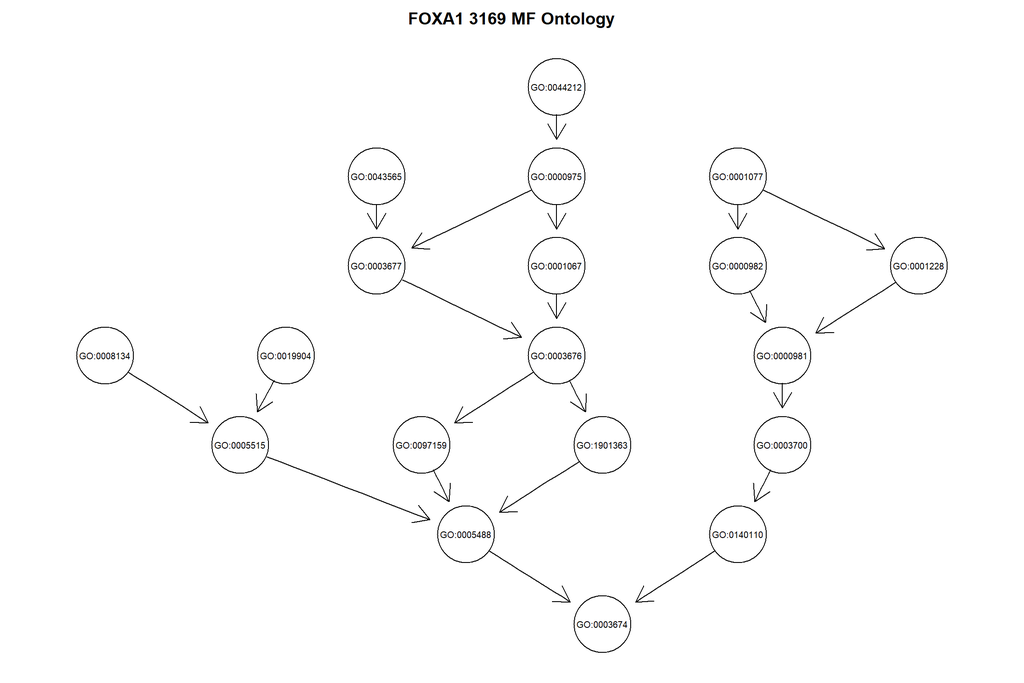

```r
require(GOstats)
graphMF1<-GOstats::makeGOGraph(info1[1,"ENTREZID"],"MF", chip="hgu133a.db")
plot(graphMF1, main=paste(info1[1,"SYMBOL"], info1[1,"ENTREZID"], "MF Ontology"), cex=3)
```

## Gene Enrichment Analysis

A gene enrichment analysis is applied on a “truncated” list of genes that one considers to be differentially expressed. In this case we take the list of what we called differentially expressed genes, but with a less restrictive p-value.

```r
selected <- topTabAvsB[,"adj.P.Val"]<0.05 & abs(topTabAvsB[,"logFC"]) > 1
sum(selected)
```

```
## [1] 434
```

```r
selectedProbes <- rownames(topTabAvsB[selected,])
selectedEntrezs <-  select(hgu133a.db, selectedProbes, "ENTREZID")[,"ENTREZID"]
```

These are checked for enrichment versus a “Universe” gene list, usually, all the genes that have entered in the analysis

```r
allProbes <- rownames(expresAvsB)
entrezUniverse = select(hgu133a.db, allProbes, "ENTREZID",  keytype="PROBEID")[,"ENTREZID"]
```

The analysis is performed by creating hyperparameters that are used to invoke the analysis functions

```r
# GOAnalysis
require(GOstats)
geneIds <- unique(selectedEntrezs)
entrezUniverse <- unique(entrezUniverse)

## Creamos los "hiperparametros" en que se basa el analisis
GOparams = new("GOHyperGParams",
               geneIds=geneIds, universeGeneIds=entrezUniverse,
               annotation="hgu133a.db", ontology="BP",
               pvalueCutoff=0.001, conditional=FALSE,
               testDirection="over")

## Ejecutamos los analisis

GOhyper = hyperGTest(GOparams)
print(head(summary(GOhyper)))
```

```
##       GOBPID       Pvalue OddsRatio  ExpCount Count Size                              Term
## 1 GO:0044255 3.828923e-09  2.527883 30.471329    64  440  cellular lipid metabolic process
## 2 GO:0006629 9.293499e-09  2.261644 41.344053    78  597           lipid metabolic process
## 3 GO:0016054 4.432234e-07  3.702811  8.310362    25  120    organic acid catabolic process
## 4 GO:0046395 4.432234e-07  3.702811  8.310362    25  120 carboxylic acid catabolic process
## 5 GO:0043436 1.569393e-06  2.043922 37.950655    67  548         oxoacid metabolic process
## 6 GO:0006082 2.179744e-06  2.020867 38.296920    67  553    organic acid metabolic process
```

It is possible to create a simple html report with the result.

```r
GOfilename =file.path(paste("GOResults.",".html", sep=""))
htmlReport(GOhyper, file = GOfilename, summary.args=list("htmlLinks"=TRUE))
```